# Forecasting Sales Time-Series with XGBoost

Sale Products: Kaggle’s mini-courses.

Author

Jorge A. Thomas

Published

July 2, 2024

## Introduction

Here I present my solution to Kaggle’s competition **Forecasting Mini-Course Sales** of 2023.

Playground Series - Season 3, Episode 19.

Using the synthetic-generated dataset (Walter Reade 2023), you’ll follow my workflow developing pipelines on the ETL phase of the Data Science cycle using the R programming language (R Core Team 2023), as well as a tidy approach to forecasting.

There was an error of the Kaggle team generating the target values of the test set in this synthetic dataset. Good forecast with the public dataset, i.e., train data deviates from the submission (test) results. **This means that the best competition results are wrong!**

For details read the following discussions:

https://www.kaggle.com/competitions/playground-series-s3e19/discussion/425538 https://www.kaggle.com/competitions/playground-series-s3e19/discussion/424133

````markdown
```{r}
#| label: Load Data
#| warning: false

sales_train_raw <- read_csv("./data/raw/train.csv") # Train, validattion and test dataset
print("Dimensions of training dataset")
dim(sales_train_raw)

sales_test_raw <- read_csv("./data/raw/test.csv")  # Features for submission dataset
print("Dimensions of test dataset containing only Feats.")
dim(sales_test_raw)

# Add Target column with NA so both DFs can be concatenated:.id
sales_test_raw <-
  sales_test_raw |>
    mutate(num_sold = NA)

# Binding and adding identifier column "dataset"
sales_all <-
  bind_rows(list(train = sales_train_raw, test = sales_test_raw), .id = "dataset")

print("Available variables:")
names(sales_all)
```
````

```
[1] "Dimensions of training dataset"
[1] 136950      6
[1] "Dimensions of test dataset containing only Feats."
[1] 27375     5
[1] "Available variables:"
[1] "dataset"  "id"       "date"     "country"  "store"    "product"  "num_sold"
```

### Count NAs

````markdown
```{r}
#| label: Counting NAs
#| code-fold: true

sales_all |>
  select(-num_sold) |>
  count_na() |>
  knitr::kable(caption = "Courses Sales dataset")
```
````

```
[1] "No missing values (NA) found."
```

Courses Sales dataset

| x |
| --- |
| No missing values (NA) found. |

### Adding temporal features

````markdown
```{r}
#' make a function of this!
#' expand_temporal_feats(datetime_colname)

sales_all <- sales_all |>
  mutate(year = year(date)) |>
  mutate(quarter = ceiling(month(date)/3)) |>
  mutate(month = month(date)) |>
  mutate(month_day = mday(date)) |>
  mutate(dow = wday(date, label = TRUE, abbr = FALSE)) |>
  mutate(is_weekend = weekdays(date)  %in% c("Saturday", "Sunday"))

# Delete "Using LLMS to " from product col

sales_all <- sales_all |>
  mutate(product = str_remove(product, "Using LLMs to "))


# Establish categorical variables
# Here these are actually "keys" to specify a single time-series

sales_all <- sales_all |>
  mutate(country = factor(country)) |>
  mutate(store = factor(store)) |>
  mutate(product = factor(product))

# cat_feats <- c("country", "store", "product")
# cat_feats <- sales_all |>
#   mutate(across(all_of(cat_feats), ~ factor(.x, ordered = FALSE)))
```
````

### Visualising Data

#### Total Sales: Aggregated Sum of Time-Series

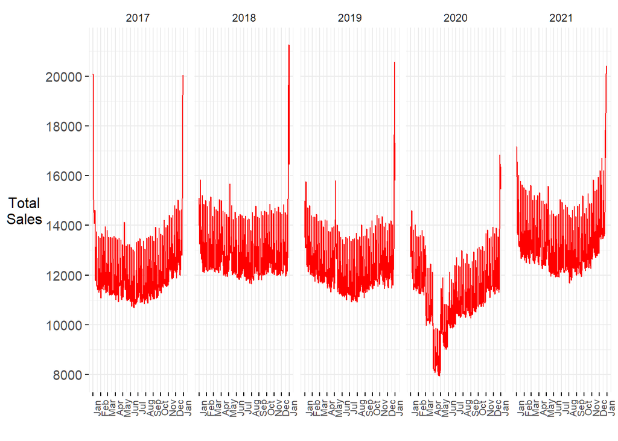

````markdown
```{r}
#| warning: false

sales_all |>
  filter(dataset == "train") |>
  group_by(date) |>
  summarise(total_sales = sum(num_sold)) |>
  mutate(year = as.factor(year(date))) |>

  ggplot(aes(x = date, y = total_sales)) +
  labs(x = "", y = "Total\nSales") +
  geom_line(colour = "red") +
  scale_x_date(date_breaks = "1 month", date_labels = "%b") +
  scale_y_continuous(breaks = seq(0, 24000, 2000)) +
  facet_wrap(~year, scales = "free_x", nrow = 1) +
  theme(axis.text.x  = element_text(angle = 90, size = 8))
```
````

#### Histogram of Total Sales (output)

Here I check the distribution of the target variable in general.

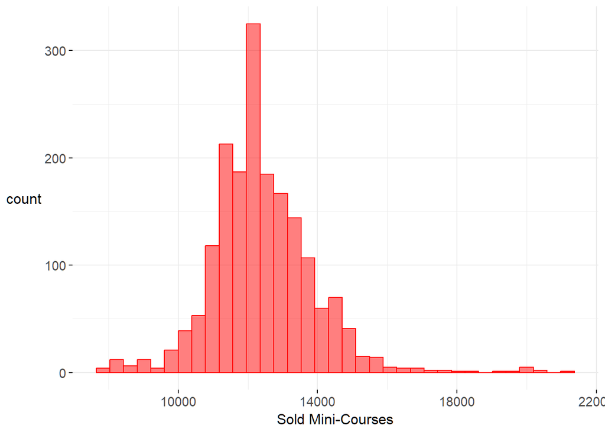

````markdown
```{r}
sales_all |>
  filter(dataset == "train") |>
  group_by(date) |>
  summarise(total_sales = sum(num_sold)) |>
  ggplot(aes(x = total_sales)) +
  geom_histogram(bins = 35, color = "red", fill = "red", alpha = 0.5) +
  # scale_x_continuous(breaks = seq(0, 800, 50), labels = scales::comma) +
  labs(x = "Sold Mini-Courses")
```
````

#### Total Sales per Country

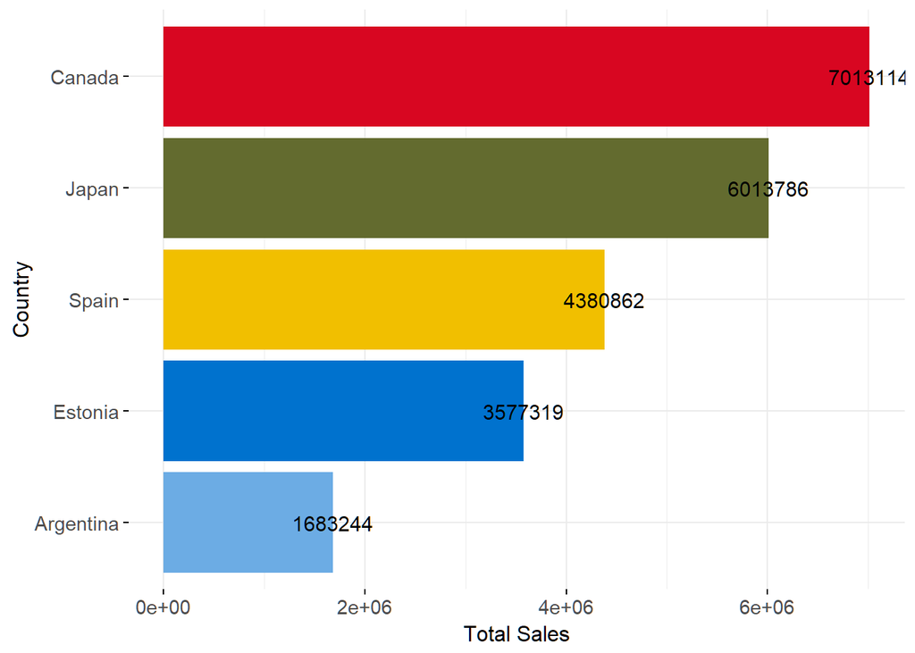

````markdown
```{r}
#| warning: false

# country_colours = c("Argentina" = "#6CACE4", "Canada" = "#D80621", "Estonia" =  "#0072CE", "Japan" = "#636B2F", "Spain" = "#F1BF00")
country_colours = c("#6CACE4", "#D80621", "#0072CE", "#636B2F", "#F1BF00")
names(country_colours) <- levels(sales_all$country)

sales_all |>
  filter(dataset == "train") |>
  group_by(country) |>
  summarise(total_sales = sum(num_sold)) |>
  ggplot(aes(y = fct_reorder(country, total_sales), x = total_sales)) +
  geom_col(aes(fill = country)) +
  geom_text(aes(label = total_sales), size = 4) +
  labs(y = "Country", x = "Total Sales") +
  scale_fill_manual(values = country_colours) +
  theme(legend.position = "none",
        axis.title.y = element_text(angle = 90))

# "%b %d" "%a %d %m %R"

# sales_all |>
#   filter(dataset == "train") |>
#   group_by(date, country) |>
#   summarise(total_sales = sum(num_sold)) |>
#   mutate(year = as.factor(year(date))) |>

#   ggplot(aes(x = date, y = total_sales)) +
#   labs(x = "", y = "Total\nSales") +
#   geom_line() +
#   scale_x_date(date_breaks = "1 month", date_labels = "%b") +
#   scale_y_continuous(breaks = seq(0, 8000, 1000)) +
#   facet_grid(country ~ year, scales = "free_x") +
#   # scale_fill_manual(values = country_colours) +
#   theme(axis.text.x  = element_text(angle = 90, size = 10) )
```
````

#### Total Daily Sales per Country

This is the train dataset

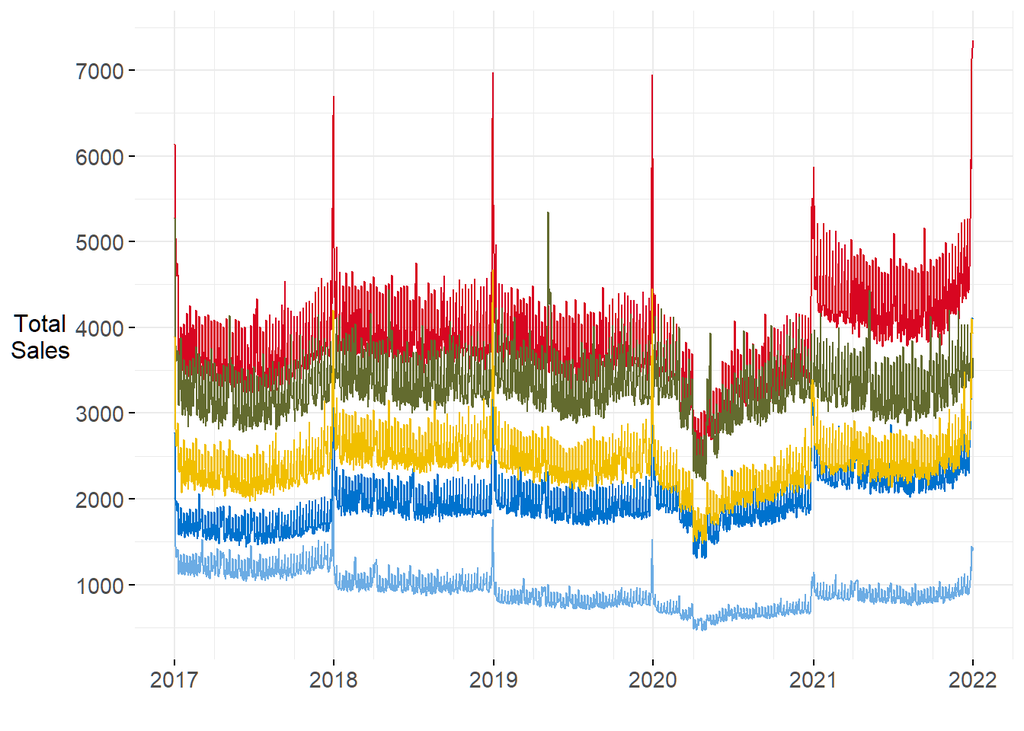

````markdown
```{r}
#| warning: false

plt_daily_sales_per_country <-
  sales_all |>
  filter(dataset == "train") |>
  group_by(date, country) |>
  summarise(total_sales = sum(num_sold)) |>
  pivot_wider(names_from = country, values_from = total_sales) |>

  ggplot(aes(x = date)) +
  labs(x = "", y = "Total\nSales") +
  geom_line(aes(y = Argentina), colour = "#6CACE4") +
  geom_line(aes(y = Canada), colour = "#D80621") +
  geom_line(aes(y = Estonia), colour = "#0072CE") +
  geom_line(aes(y = Japan), colour = "#636B2F") +
  geom_line(aes(y = Spain), colour = "#F1BF00") +
  scale_x_date(date_breaks = "1 years", date_minor_breaks = "6 months", date_labels = "%Y") +
  scale_y_continuous(breaks = seq(0, 8000, 1000))

plot(plt_daily_sales_per_country)
#  plotly::ggplotly(plt_daily_sales_per_country)
```
````

- The effects of the **pandemic** are clear, more stronlgy during the lock-down period.
- During the last week of every year, i.e., christmas holidays, sales spike.

#### Most Popular Courses

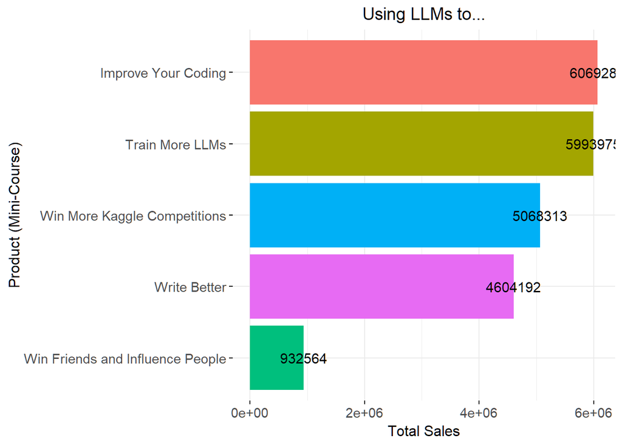

````markdown
```{r}
sales_all |>
  filter(dataset == "train") |>
  group_by(product) |>
  summarise(total_sales = sum(num_sold)) |>
  ggplot(aes(y = fct_reorder(product, total_sales), x = total_sales)) +
  geom_col(aes(fill = product)) +
  geom_text(aes(label = total_sales), size = 4) +
  labs(title = "Using LLMs to..." ,y = "Product (Mini-Course)", x = "Total Sales") +
  theme(legend.position = "none", axis.title.y = element_text(angle = 90))
```
````

It seems that LLMs are not that useful to win friends and influence people…

### Add Pandemic and Holidays Flags

One can see clearly the pandemic effect starting on March 2020. A feature flag should be added.

````markdown
```{r}
sales_all$pandemy <- FALSE
sales_all$pandemy[which(sales_all$year == 2020)] <- TRUE

sales_all$holiday <- FALSE
sales_all$holiday[which(sales_all$month == 12 & sales_all$month_day > 23)] <- TRUE
sales_all$holiday[which(sales_all$month == 1 & sales_all$month_day > 1)] <- TRUE

# Japan National Holidays (Sales spike)
sales_all$holiday[which(sales_all$country == "Japan", sales_all$month == 5 & sales_all$month_day > 2 & sales_all$month_day < 6)] <- TRUE
```
````

#### Total Daily Sales per Product (Mini-Courses)

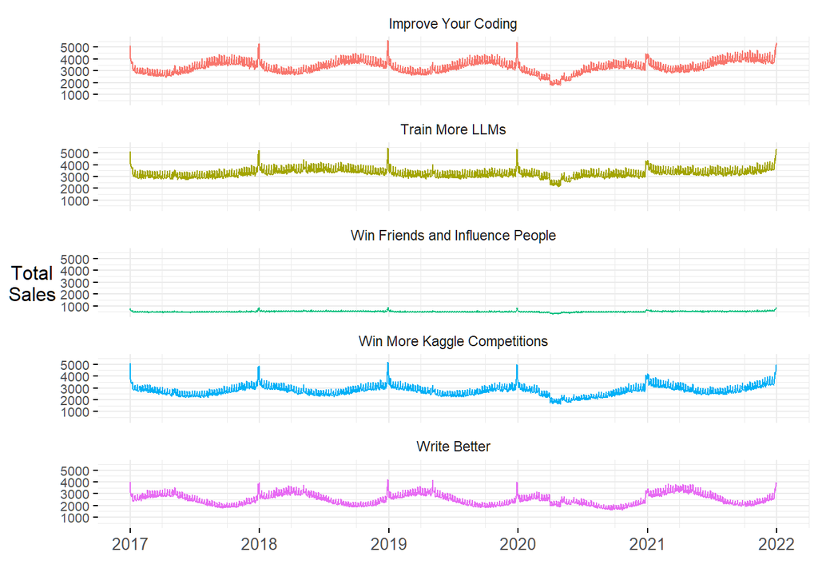

````markdown
```{r}
sales_all |>
  filter(dataset == "train") |>
  group_by(date, product) |>
  summarise(total_sales = sum(num_sold)) |>
  # pivot_wider(names_from = product, values_from = total_sales) |>

  ggplot(aes(x = date, y = total_sales)) +
  labs(x = "", y = "Total\nSales") +
  geom_line(aes(colour = product)) +
  scale_x_date(date_breaks = "1 years", date_minor_breaks = "6 months", date_labels = "%Y") +
  scale_y_continuous(breaks = seq(0, 6000, 1000)) +
  facet_wrap(~product, ncol = 1) +
  # scale_fill_manual(values = country_colours) +
  theme(legend.position = "none",
        axis.text.x  = element_text(angle = 0, size = 10),
        axis.text.y = element_text(size = 8))
```
````

## Training Forecast Models

### ETS and ARIMA

Considering that *country*, *store*, and *product* are keys, there are 75 time-series in total to model.

````markdown
```{r}
sales <- sales_all |>
  filter(dataset == "train") |>
  select(-c("id", "dataset")) |>
  as_tsibble(key = c(country, store, product), index = date)

# tsibble::interval(sales)
# tsibble::is_regular(sales)
# sales

# Train (fit) models (35 minutes approx.)

#tic("Training ETS and ARIMA models")

#sales_fit <- sales %>%
#  model(ets = ETS(num_sold), arima = ARIMA(num_sold)) %>%
#  mutate(ensemble = (ets + arima)/2)

#toc()
# saveRDS(sales_fit, file = "./models/ets_arima.rds")
sales_fit <- readRDS("./models/ets_arima.rds")

sales_fit
```
````

```
# A tibble: 75 × 6
   country   store       product           ets                             arima
   <fct>     <fct>       <fct>         <model>                           <model>
 1 Argentina Kagglazon   Improv…  <ETS(M,A,M)>          <ARIMA(3,0,1)(2,1,0)[7]>
 2 Argentina Kagglazon   Train … <ETS(M,Ad,M)>          <ARIMA(2,0,2)(0,1,2)[7]>
 3 Argentina Kagglazon   Win Fr… <ETS(M,Ad,M)>          <ARIMA(4,0,0)(1,1,1)[7]>
 4 Argentina Kagglazon   Win Mo… <ETS(M,Ad,M)>          <ARIMA(4,0,0)(1,1,1)[7]>
 5 Argentina Kagglazon   Write … <ETS(M,Ad,M)>          <ARIMA(2,0,2)(2,1,0)[7]>
 6 Argentina Kaggle Lea… Improv… <ETS(M,Ad,M)>          <ARIMA(3,0,1)(2,1,0)[7]>
 7 Argentina Kaggle Lea… Train … <ETS(M,Ad,M)> <ARIMA(1,0,0)(1,1,0)[7] w/ drift>
 8 Argentina Kaggle Lea… Win Fr…  <ETS(M,N,M)>          <ARIMA(2,1,1)(2,0,0)[7]>
 9 Argentina Kaggle Lea… Win Mo… <ETS(M,Ad,M)>          <ARIMA(2,0,2)(0,1,2)[7]>
10 Argentina Kaggle Lea… Write …  <ETS(M,N,M)>          <ARIMA(1,0,0)(1,1,1)[7]>
# ℹ 65 more rows
# ℹ 1 more variable: ensemble <model>
```

### Visualising Forecasts

Picking one Time-Series (from 75) to visualise model performances.

#### Canada’s sales of “Improve Your Coding course” on Kagglazon

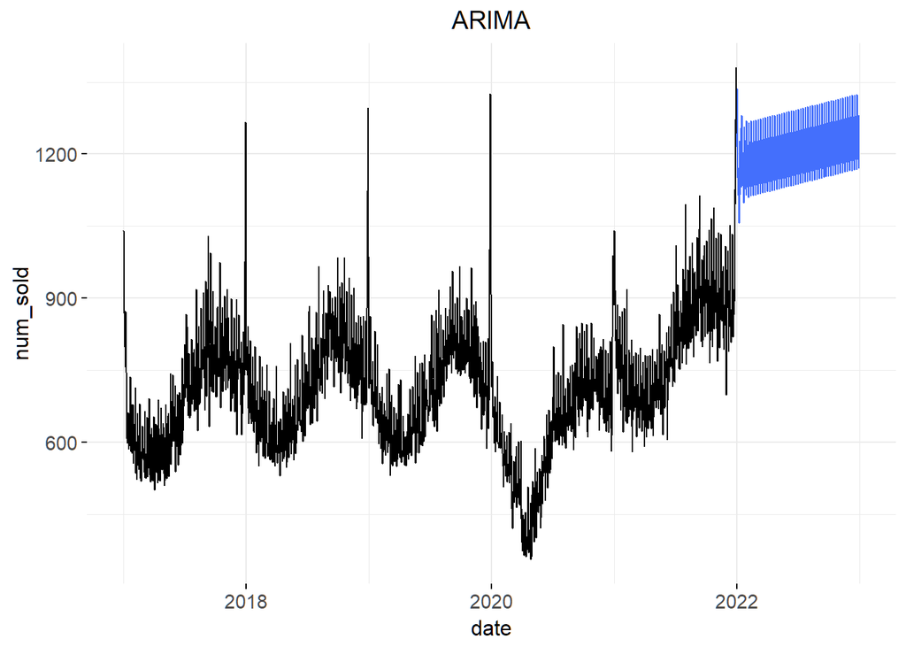

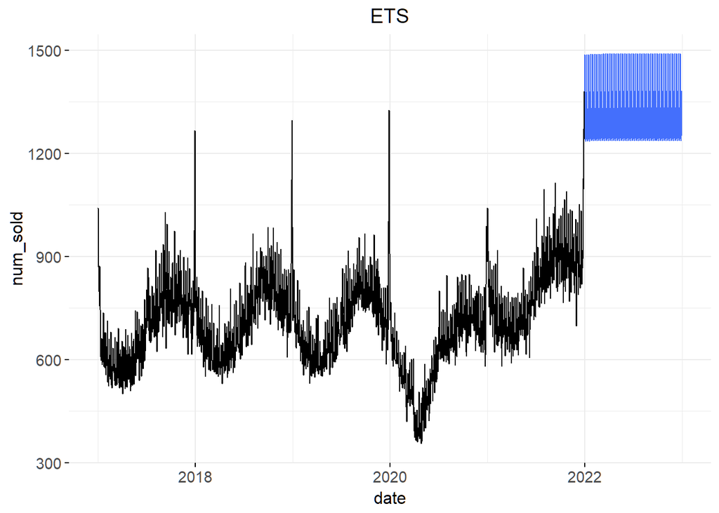

````markdown
```{r}
#| label: forecast

sales_fc <- sales_fit |> forecast(h = "1 years")
# sales_fc

# test <- sales_arima_fc %>% accuracy(sales, measures = list(MSE=MSE, CRPS=CRPS))

# Vis
sales_fc |>
  filter(.model == "arima", country == "Canada", store == "Kagglazon", product == "Improve Your Coding") |>
  autoplot(sales, level = NULL) +
  labs(title = "ARIMA") + theme(axis.title.y = element_text(angle = 90))

sales_fc |>
  filter(.model == "ets", country == "Canada", store == "Kagglazon", product == "Improve Your Coding") |>
  autoplot(sales, level = NULL) +
  labs(title = "ETS") + theme(axis.title.y = element_text(angle = 90))

# sales_fc |>
#   filter(.model == "ensemble", country == "Canada", store == "Kagglazon", product == "Improve Your Coding") |>
#   autoplot(sales, level = NULL) +
#   labs(title = "Ensemble")

#left_join
```
````

## References

R Core Team. 2023. *R: A Language and Environment for Statistical Computing*. Vienna, Austria: R Foundation for Statistical Computing. https://www.R-project.org/.

Walter Reade, Ashley Chow. 2023. “Forecasting Mini-Course Sales.” Kaggle. https://kaggle.com/competitions/playground-series-s3e19.